# BLK-stock-analysis

```python
import pandas as pd
import numpy as np
import matplotlib.pyplot as plt
import scipy.stats as stats
import math
```

### Analysis of BlackRock Inc (BLK)

Data consists of stock prices for BlackRock Inc (BLK) in the time period 2019-11-11 until 2022-11-10  
Datasource: finance.yahoo.com

```python
def load_csv(file):
    df = pd.read_csv(file)

    # Calculate returns and put into a new column
    df['Returns'] = df['Close'].pct_change()

    return df


# Read in historical data of BlackRock Inc from Yahoo Finance
blk_df = load_csv('data/BLK.csv')
azn_df = load_csv('data/AZN.csv')
sp100_df = load_csv('data/OEX.csv')
omx30_df = load_csv('data/OMX.csv')

pd.options.mode.chained_assignment = None #Removes error that otherwise occur in for-loop (default='warn')

def scale_index(index_df, stock_df):
    # Scale index to start at same price as stock
    index_df['adjReturn'] = stock_df['Close']
    for i in range(1, len(stock_df)):
        index_df['adjReturn'][i] = index_df['adjReturn'][i-1]*(1+index_df['Returns'][i])

scale_index(sp100_df, blk_df)
scale_index(omx30_df, azn_df)
```

Close = Close price adjusted for splits.  
Adj Close = Adjusted close price adjusted for splits and dividend and/or capital gain distributions.

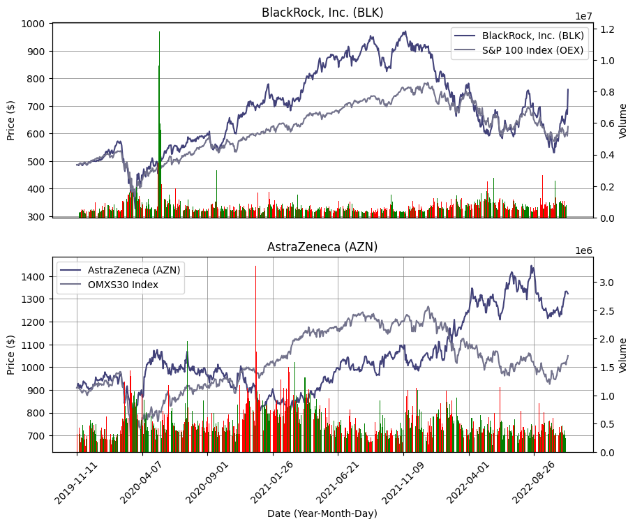

```python
def plot_stock_price(ax, title, legend, stock_df, index_df):
    ax.set_title(title)
    ax.set_ylabel('Price ($)')
    ax.plot(stock_df['Date'], stock_df['Close'], color='#424279')
    ax.plot(index_df['Date'], index_df['adjReturn'], color = '#73738C')
    ax.grid(color = 'grey', linewidth = 0.5)
    ax.legend(legend)
    ax.set_xlabel('Date (Year-Month-Day)')
    ax.set_xticks(np.arange(0, len(index_df)+1, 100))
    ax.tick_params(axis='x',labelrotation=45)
    ax2=ax.twinx()
    ax2.bar(stock_df['Date'], stock_df['Volume'], color = stock_df['Returns'].apply(lambda x: 'green' if x > 0 else 'red'))
    ax2.set_ylabel('Volume')

fig, ax = plt.subplots(2)
fig.set_size_inches(10, 8)
plot_stock_price(ax[0], 'BlackRock, Inc. (BLK)', ['BlackRock, Inc. (BLK)', 'S&P 100 Index (OEX)'], blk_df, sp100_df)
plot_stock_price(ax[1], 'AstraZeneca (AZN)', ['AstraZeneca (AZN)', 'OMXS30 Index'], azn_df, omx30_df)
ax[0].set_xlabel(None)
ax[0].set_xticks([])
plt.show()
```

For this project I decided to study the American investment company BlackRock. In the graph above you can see the development of the stock over a three year long time period between 2019-11-11 to 2022-11-10 and it's relative performance compared to the index S&P100. The barplot at the bottom of the graph shows the traded volume over the same period, with red corresponding to a negative day and green to a positive day.

# Returns

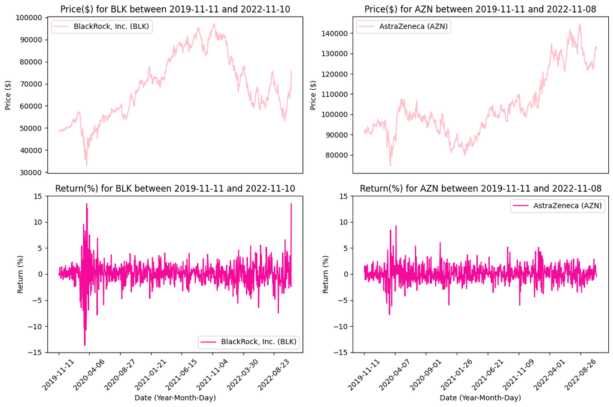

```python
def plot_returns(name, ticker, df, axs):
    x = df['Date']
    y1 = df['Close']
    y2 = df['Returns']

    # Remove x-axis ticks
    start_date = df['Date'][0]
    end_date = list(df['Date'])[-1]
    axs[0].set_title(f'Price($) for {ticker} between {start_date} and {end_date}')
    axs[0].set_xticks([])
    axs[0].set_xticklabels([])
    axs[0].set_ylabel('Price ($)')
    axs[0].plot(x, y1*100, color = 'pink')
    axs[0].legend([f'{name} ({ticker})'])
    axs[1].set_title(f'Return(%) for {ticker} between {start_date} and {end_date}')
    axs[1].tick_params(axis='x', labelrotation = 45)
    axs[1].set_xticks(np.arange(0, len(x)+1, 100))
    axs[1].set_xlabel('Date (Year-Month-Day)')
    axs[1].set_ylabel('Return (%)')
    axs[1].plot(x, y2*100, c='#F30A9A')
    axs[1].legend([f'{name} ({ticker})'])
    axs[1].set_ylim([-15, 15])
    fig.tight_layout()

fig, axs = plt.subplots(2, 2)
fig.set_size_inches(12, 8)
plot_returns('BlackRock, Inc.', 'BLK', blk_df, (axs[0][0], axs[1][0]))
plot_returns('AstraZeneca', 'AZN', azn_df, (axs[0][1], axs[1][1]))
plt.show()
```

**Describe the process**  
We can see that volatility clusters were periods with large negative return often also contains days with large positive return. This can especielly be shown in the period of the Covid-crash in 2020 were we see returns of both negative and positive ~15%.

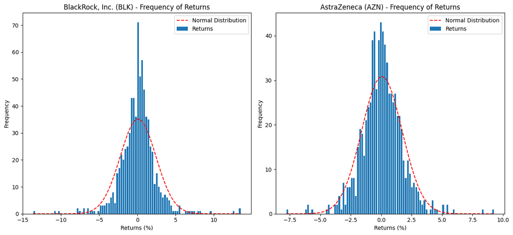

```python
def plot_freq(df_column, title, ax):
    mu = df_column.mean()
    sigma = df_column.std()

    num_bins = 100

    # the histogram of the data
    freqs, bins, patches = ax.hist(df_column, num_bins, rwidth=0.8)

    # add a normal distribution line
    y = stats.norm.pdf(bins, mu, sigma)
    y = y*sum(freqs)*(bins[1]-bins[0]) # same area
    ax.plot(bins, y, '--', color = 'red')
    ax.set_xlabel('Returns (%)')
    ax.set_ylabel('Frequency')
    ax.legend(['Normal Distribution', 'Returns'])
    ax.set_title(title)

fig, ax = plt.subplots(1, 2)
fig.set_size_inches(13, 6)
plot_freq(blk_df['Returns']*100, 'BlackRock, Inc. (BLK) - Frequency of Returns', ax[0])
plot_freq(azn_df['Returns']*100, 'AstraZeneca (AZN) - Frequency of Returns', ax[1])
fig.tight_layout()
plt.show()
```

**How does this histogram differ from e.g. a normal distribution?**  
Even though the rough features of the histogram seems to follow the bell shaped curve we can see that the returns don't follow the normal distribution when studied in more detail. The most noticable thing here is that as the normal distribution goes towards zero which makes it totally ignore the days with the most fluctuation in price. Ignoring these days can completely crash your portfolio, especially if what you buy contains high leverage.

Apart from the longer tails, the returns also deviates from the normal distribution in that the peak is taller. It is more common with days with around 0% return than the normal distribution would predict. On the other hand, the middle-sized returns of around 2% - 5% (both positive and negative) are less common than if the returns followed a normal ditribution.

https://medium.com/swlh/how-confusing-a-fat-tailed-for-a-normal-distribution-will-kill-your-platform-strategy-fb3caf58385d

# 20-day daily volatility window

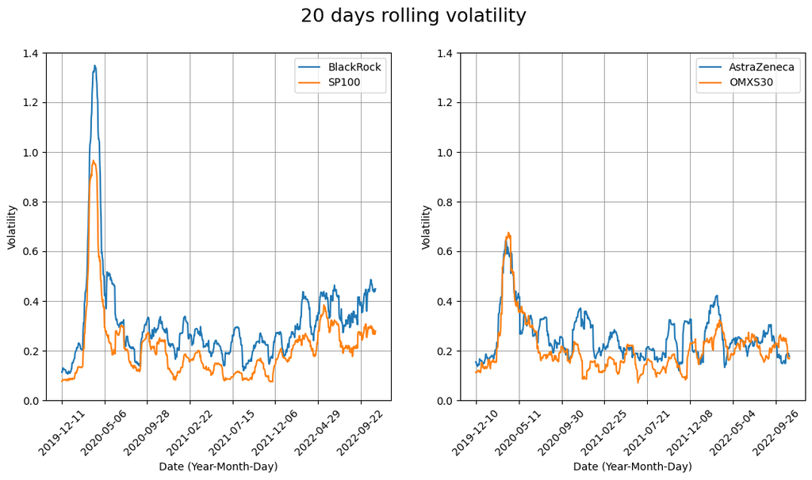

```python
def calculate_volatility(df, T):
    closing_prices = list(df['Close'])
    R_hat = [] # log return
    for i in range(1, len(closing_prices)):
        R_hat.append(math.log(closing_prices[i]) - math.log(closing_prices[i-1]))

    volatility_T = []
    for i in range(T, len(R_hat)):
        R_hat_avg = 1/len(closing_prices) * math.log(closing_prices[i-1] / closing_prices[0])
        s = 0
        for R in R_hat[i-T : i]:
            s += (R-R_hat_avg)**2
        volatility_T.append(math.sqrt(252) * math.sqrt(1/(T-1) * s))
    return volatility_T

def plot_volatility(df, index_df, days, legend, ax, ymax):
    x = df['Date']
    sigma_stock = np.array(calculate_volatility(df, days))
    sigma_index = np.array(calculate_volatility(index_df, days))
    ax.plot(x[days+1:], sigma_stock)
    ax.plot(x[days+1:], sigma_index)
    ax.legend(legend)
    ax.set_xticks(np.arange(0, len(x)-days, 100))
    ax.set_xlabel('Date (Year-Month-Day)')
    ax.tick_params(axis='x', labelrotation = 45)
    ax.set_ylabel('Volatility')
    ax.set_ylim([0, ymax])
    ax.grid(color = 'grey', linewidth = 0.5)

fig, ax = plt.subplots(1, 2)
fig.set_size_inches(13, 6)
fig.suptitle('20 days rolling volatility', fontsize=18)
plot_volatility(blk_df, sp100_df, 20, ["BlackRock", 'SP100'], ax[0], 1.4)
plot_volatility(azn_df, omx30_df, 20, ["AstraZeneca", 'OMXS30'], ax[1], 1.4)
plt.show()
```

The volatility looks to be following a mean reversion pattern, which is very similar to how the time series of brownian motion works.

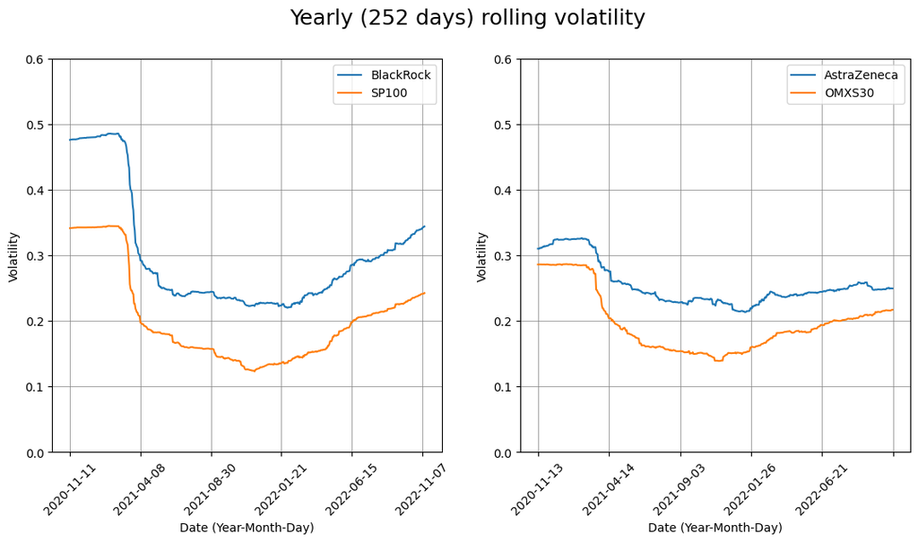

```python
fig, ax = plt.subplots(1, 2)
fig.set_size_inches(13, 6)
fig.suptitle('Yearly (252 days) rolling volatility', fontsize=18)
plot_volatility(blk_df, sp100_df, 252, ["BlackRock", 'SP100'], ax[0], 0.6)
plot_volatility(azn_df, omx30_df, 252, ["AstraZeneca", 'OMXS30'], ax[1], 0.6)
plt.show()
```

```python
print("BlackRock average volatility:", calculate_volatility(blk_df, len(blk_df)-2)[0]*100)
print("AstraZeneca average volatility:", calculate_volatility(azn_df, len(azn_df)-2)[0]*100)
```

```
BlackRock average volatility: 36.27071737931667
AstraZeneca average volatility: 26.300962857748424
```

# Returns divided by volatility estimates for each day

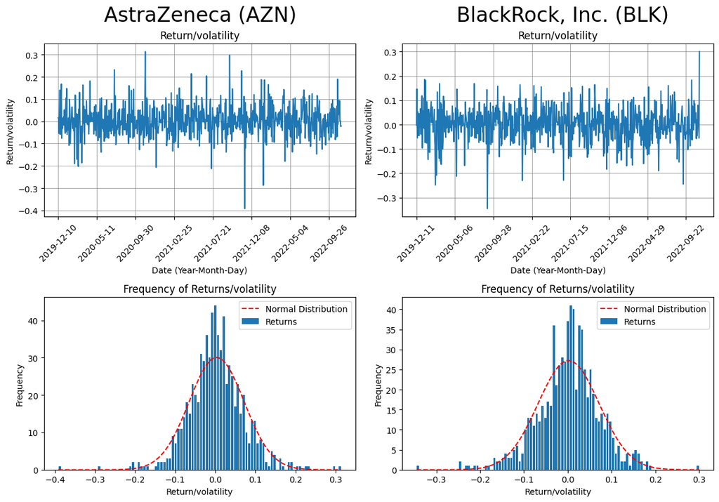

```python
def plot_return_divided_by_volatility_and_histogram(df, ax, company):
    returns = df['Returns'][21:]
    volatility = calculate_volatility(df, 20)

    ax[0].plot(df['Date'][21:], returns/volatility)
    ax[0].set_title(f'Return/volatility')
    ax[0].tick_params(axis='x', labelrotation = 45)
    ax[0].set_xticks(np.arange(0, len(returns)+1, 100))
    ax[0].set_xlabel('Date (Year-Month-Day)')
    ax[0].set_ylabel('Return/volatility')
    ax[0].grid(color = 'grey', linewidth = 0.5)

    plot_freq(returns/volatility, 'Frequency of Returns/volatility', ax[1])
    ax[1].set_xlabel("Return/volatility")

fig, ax = plt.subplots(2, 2)
plot_return_divided_by_volatility_and_histogram(azn_df, (ax[0][0], ax[1][0]), 'AstraZeneca (AZN)')
plot_return_divided_by_volatility_and_histogram(blk_df, (ax[0][1], ax[1][1]), 'BlackRock, Inc. (BLK)')
fig.text(.28, 1, 'AstraZeneca (AZN)', fontsize=24, horizontalalignment='center')
fig.text(.78, 1, 'BlackRock, Inc. (BLK)', fontsize=24, horizontalalignment='center')
fig.set_size_inches(12, 8)
fig.tight_layout()
plt.show()
```

The return/volatility graphs look similar to the return graphs from before except that the volatility looks constant now since we divided away the volatility.

The histograms look like before; kind of normal distributed but with longer tails.

# BlackRock option

https://finance.yahoo.com/quote/BLK221209C00710000?p=BLK221209C00710000

Date: 2 dec  
Type: Call  
Closing price: 9.25 USD  
Strike: 710 USD  
Expiration date: 2022-12-09  
BLK price: 712.98 USD

# AstraZeneca option

https://finance.yahoo.com/quote/AZN221209C00069000?p=AZN221209C00069000

Date: 2 dec  
Type: Call  
Closing price: 0.51 USD  
Strike: 69.00  
Expiration date: 2022-12-09  
AZN price: 68.47 USD